# HW3

Sinclair Stockard

October 15, 2018

## Question 1a

There are 28,947 probes.

```r
setwd('/Users/sincl/OneDrive/Desktop')

load(file.path("ProstateData", "expression.data.rda"))
load(file.path("ProstateData", "clinical.info.rda"))
load(file.path("ProstateData", "gene.info.rda"))

dim(expression.data)
```

```
## [1] 28947   112
```

```r
expression.data[1:5,1:5]
```

```
##          PL129        PL27      PL122      PL133      PL194
## X1  0.14246812 -0.96968166 -0.6875246 -0.9696671 -0.3718667
## X2 -0.27210088 -1.33995685 -1.3664423 -0.1511050  0.1263064
## X3 -0.25054315 -1.39735526 -0.7106404 -0.4746258 -0.3231313
## X4 -0.27872714 -0.04575312  0.1758693 -0.9794424 -0.5691547
## X5 -0.03232265 -0.76169375  0.1021376 -0.8874428 -0.5580851
```

## Question 1b

There are 10,204 unique genes.

```r
str(gene.info)
```

```
## 'data.frame':    28947 obs. of  6 variables:
##  $ ArrayI.Spot : int  1 2 3 4 5 6 7 8 9 10 ...
##  $ ArrayII.Spot: int  145 146 147 148 149 150 151 152 3657 3658 ...
##  $ Clone.ID    : Factor w/ 26922 levels "*mitoch. cont. IMAGE:1009909",..: 15481 11779 19496 1720 11829 8096 24138 8784 14182 1250 ...
##  $ Gene.Symbol : Factor w/ 10204 levels "","101F6","13CDNA73",..: 4589 4451 6570 4207 3755 4408 8453 8112 1795 1 ...
##  $ Cluster.ID  : Factor w/ 18030 levels "","Hs.100007",..: 10113 12153 3422 17244 15202 3535 17214 13619 17517 1 ...
##  $ Accession   : Factor w/ 26808 levels "","AA001103",..: 26212 19638 18514 22553 19603 24574 4684 24516 21829 25686 ...
```

## Question 1c

```r
summary(gene.info)
```

```
##   ArrayI.Spot     ArrayII.Spot                          Clone.ID
##  Min.   :    1   Min.   :    1   IMAGE:153541               :    9
##  1st Qu.: 7640   1st Qu.: 8016   *mitoch. cont. IMAGE:511952:    4
##  Median :29198   Median :28126   IMAGE:1069358              :    4
##  Mean   :25239   Mean   :24390   IMAGE:1070038              :    4
##  3rd Qu.:36837   3rd Qu.:35669   IMAGE:1070062              :    4
##  Max.   :44536   Max.   :43196   IMAGE:108208               :    4
##                                  (Other)                    :28918
##   Gene.Symbol        Cluster.ID       Accession
##         :12348            : 2826           :  118
##  GLS    :   15   Hs.128410:   15   AI732309:    9
##  ASCL1  :   13   Hs.1619  :   13   AA004415:    4
##  EPHB1  :   13   Hs.272311:   13   AA019995:    4
##  PRKCBP1:   11   Hs.388682:   10   AA047418:    4
##  CEPT1  :    9   Hs.102267:    9   AA053226:    4
##  (Other):16538   (Other)  :26061   (Other) :28804
```

## Question 1d

There are 112 samples.

```r
dim(clinical.info)
```

```
## [1] 112   6
```

```r
clinical.info[1:5,1:5]
```

```
##       Arrays Reference Sample Status Subgroups
## PL129 p16113     CRG13  PL129      L       III
## PL27  p17934     CRG23   PL27      L        II
## PL122 p17935     CRG24  PL122      L       III
## PL133 p17937     CRG25  PL133      L       III
## PL194 p22772     CRG64  PL194      L       III
```

## Question 1e

41 samples normal (Status = N) 62 samples tumor (Status = T) 9 samples lymphnode metastases (Status = L)

```r
str(clinical.info)
```

```
## 'data.frame':    112 obs. of  6 variables:
##  $ Arrays   : Factor w/ 112 levels "p16090","p16093",..: 13 23 24 25 64 65 95 96 97 1 ...
##  $ Reference: Factor w/ 112 levels "CRG1","CRG10",..: 18 29 30 31 74 75 108 109 110 1 ...
##  $ Sample   : Factor w/ 112 levels "PL114","PL115",..: 6 9 5 7 8 4 1 2 3 43 ...
##  $ Status   : Factor w/ 3 levels "L","N","T": 1 1 1 1 1 1 1 1 1 2 ...
##  $ Subgroups: Factor w/ 5 levels "I","II","III",..: 3 2 3 3 3 3 3 3 3 4 ...
##  $ ChipType : Factor w/ 2 levels "new","old": 2 2 2 2 1 1 1 1 1 2 ...
```

```r
Status <- clinical.info$Status

freqtable <- table(Status)
t = as.data.frame(freqtable)

t
```

```
##   Status Freq
## 1      L    9
## 2      N   41
## 3      T   62
```

## Question 2a

```r
T <- (which(clinical.info$Status == "T"))
L <- (which(clinical.info$Status == "L"))
filtdata <- expression.data[, c(T, L)]
filtclin <- clinical.info[c(T, L),]
filtclin$Status <- factor(filtclin$Status)
```

## Question 2b

```r
library(ClassComparison)
```

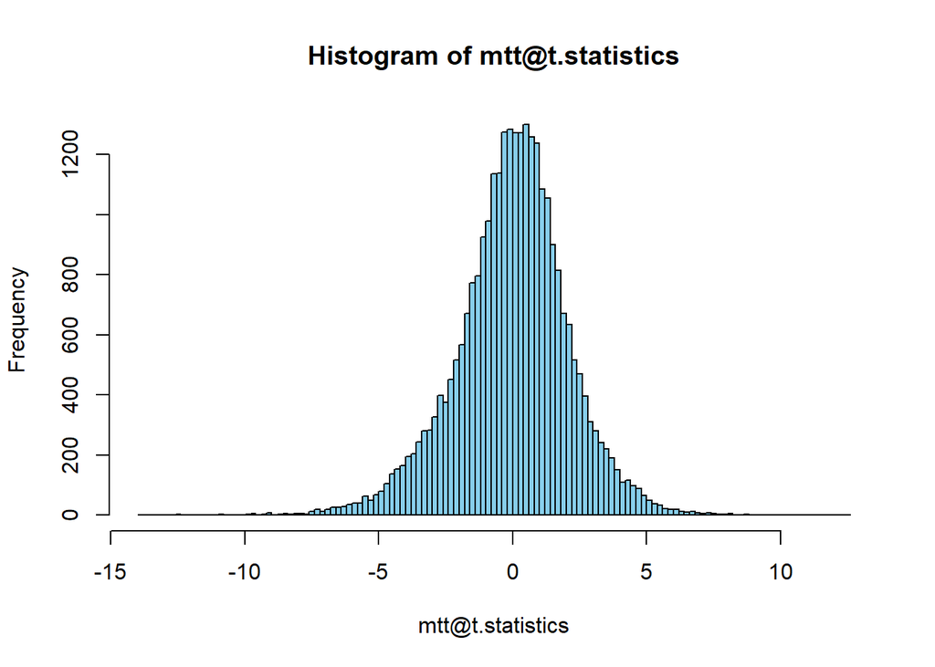

```r
mtt <- MultiTtest(filtdata, filtclin$Status)
hist(mtt@t.statistics, breaks=100, col='skyblue')
```

## Question 2c

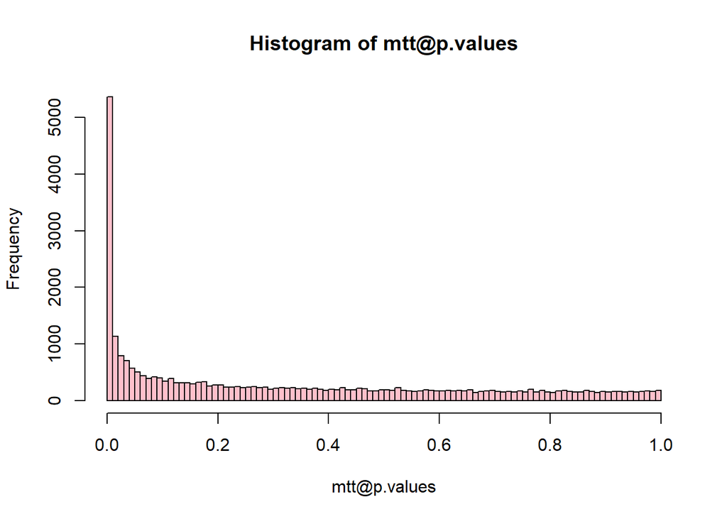

```r
hist(mtt@p.values, breaks=100, col='pink')
```

## Question 2d

There are 5358 p-values < .01. This is more than what is expected by chance (0.01 * 28947 = 289.5).

```r
p.val <- mtt@p.values
sum(p.val < 0.01)
```

```
## [1] 5358
```

## Question 2e

There are 8574 p-values < .05. This is more than what is expected (1447.35).

```r
sum(p.val < 0.05)
```

```
## [1] 8574
```

## Question 3a

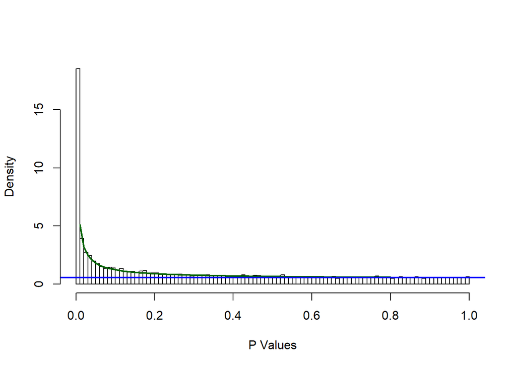

```r
bum <- Bum(mtt@p.values)
hist(bum)
```

## Question 3a

There are 3666 genes differentially expressed.

```r
countSignificant(bum, alpha=0.01, by="FDR")
```

```
## [1] 3666
```

## Question 3b

There are 6568 genes differentially expressed.

```r
countSignificant(bum, alpha=0.05, by="FDR")
```

```
## [1] 6568
```

## Question 4a

```r
status <- filtclin[, "Status"]

wiltest <- MultiWilcoxonTest(filtdata, status)
```

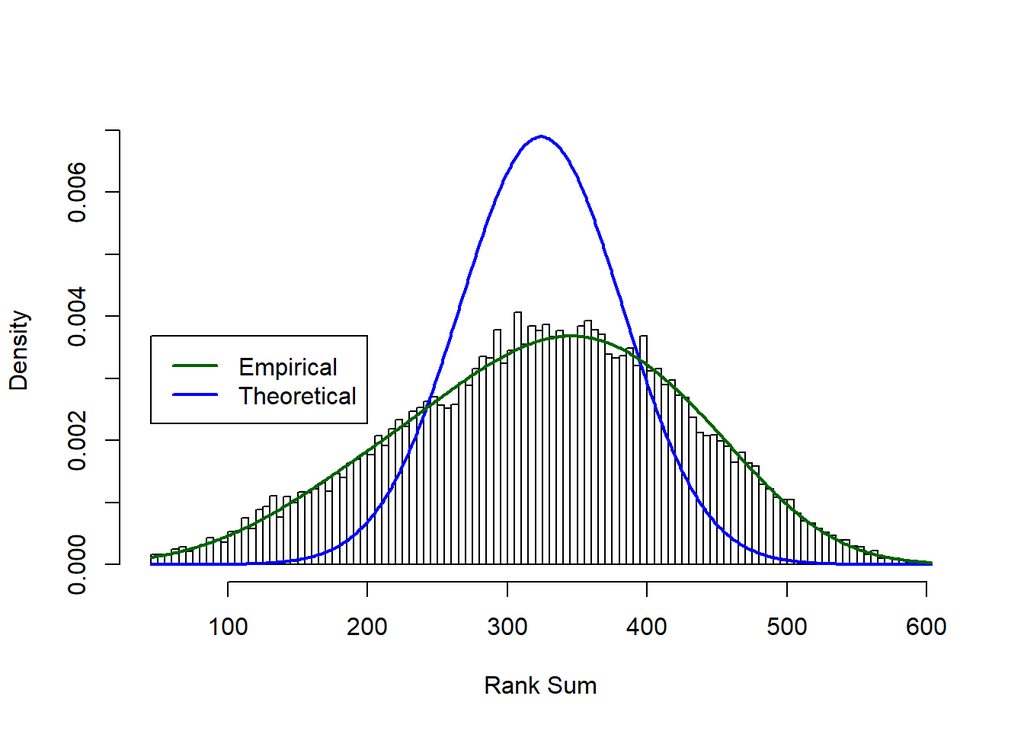

```r
hist(wiltest, breaks = 100, col='orange')
```

## Question 4b

```r
require(ClassComparison)
wilc <- MultiWilcoxonTest(filtdata, status)
```

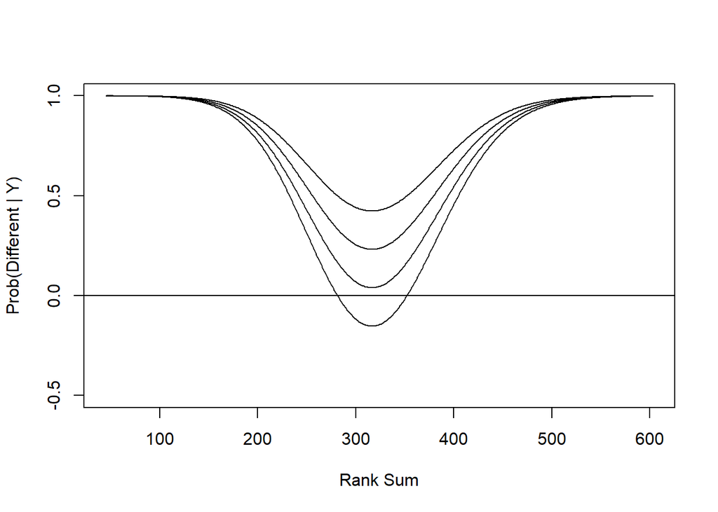

```r
plot(wilc, prior=c(0.30, 0.40, 0.50, .60), signif=NULL)

abline(h=0)
```

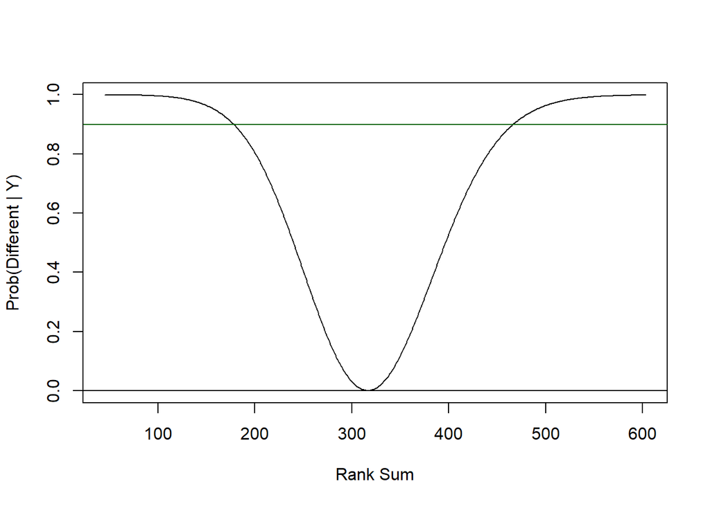

```r
plot(wilc, prior=0.52 , ylim=c(0,1))
abline(h=0)
```

## Question 4c

```r
cutoffSignificant(wilc, prior=0.52, signif=0.9)
```

```
## $low
## [1] 179
##
## $high
## [1] 466
```

## Question 5a

Yes, similar numbers of L samples were run on new and old chips, but far more N and T samples were run on new chips.

```r
summary(clinical.info)
```

```
##      Arrays      Reference       Sample    Status Subgroups ChipType
##  p16090 :  1   CRG1   :  1   PL114  :  1   L: 9   I  :11    new:86
##  p16093 :  1   CRG10  :  1   PL115  :  1   N:41   II :39    old:26
##  p16095 :  1   CRG100 :  1   PL116  :  1   T:62   III:19
##  p16097 :  1   CRG101 :  1   PL118.3:  1          N  :41
##  p16098 :  1   CRG102 :  1   PL122  :  1          O  : 2
##  p16101 :  1   CRG103 :  1   PL129  :  1
##  (Other):106   (Other):106   (Other):106
```

```r
newchip <- clinical.info[clinical.info$ChipType %in% c('new'),]

StatusNew <- newchip$Status

freqtable2 <- table(StatusNew)
t2 = as.data.frame(freqtable2) ##Distribution of sample types for 'new' chips

t2
```

```
##   StatusNew Freq
## 1         L    5
## 2         N   32
## 3         T   49
```

```r
oldchip <- clinical.info[clinical.info$ChipType %in% c('old'),]

StatusOld <- oldchip$Status

freqtable3 <- table(StatusOld)
t3 = as.data.frame(freqtable3) ##Distribution of sample types for 'old' chips

t3
```

```
##   StatusOld Freq
## 1         L    4
## 2         N    9
## 3         T   13
```

## Question 5b

Chip Type seems to have more of an overall impact on data. All of the old samples are clustered together in one branch whereas status varies within branches.

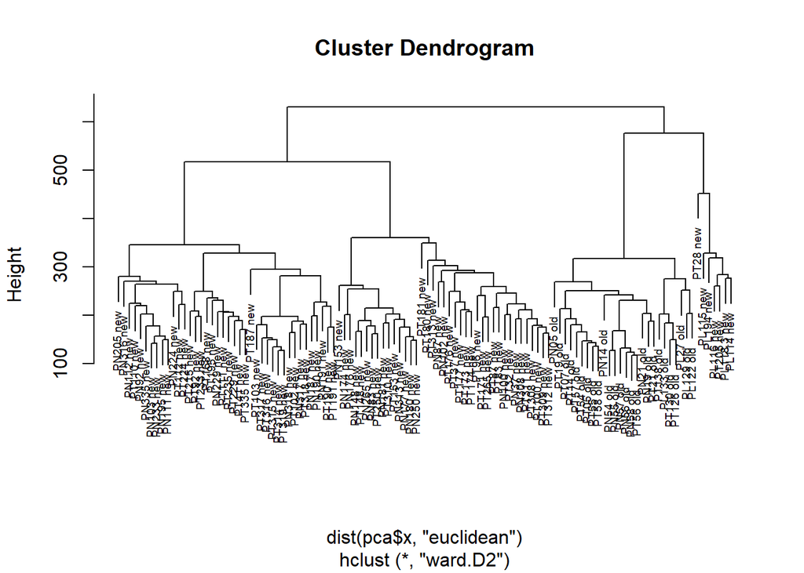

```r
expression.data2 <- as.data.frame(t(expression.data))

rownames(expression.data2) = paste(rownames(expression.data2), as.character(clinical.info$ChipType))

pca <- prcomp(expression.data2, scale = TRUE)

clust = hclust(dist(pca$x, "euclidean"), method = "ward.D2")

plot(clust, cex = .6)
```

## Question 6a

```r
Histology <- as.data.frame(clinical.info$Status)
rownames(Histology) = rownames(clinical.info)
colnames(Histology) = "Status"
mlm <- MultiLinearModel(Y ~ Status, Histology, expression.data)
summary(mlm)
```

```
## Row-by-row linear models with 28947 rows
##
## Call: MultiLinearModel(form = Y ~ Status, clindata = Histology, arraydata = expression.data)
##
## F-statistics:
##      Min.   1st Qu.    Median      Mean   3rd Qu.      Max.
##   0.00009   0.84853   2.34720   5.54190   6.23389 203.88197
##
## P-values:
```

```
##     Min.  1st Qu.   Median     Mean  3rd Qu.     Max.
## 0.000000 0.002733 0.100454 0.244685 0.430851 0.999907
```

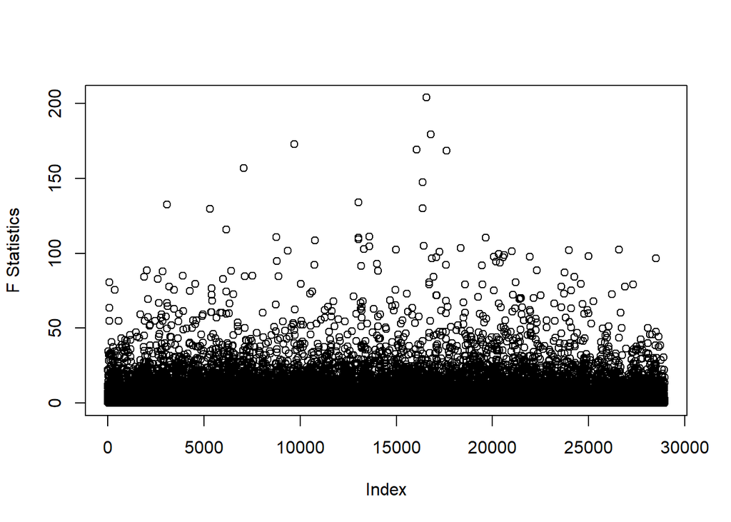

```r
plot(mlm)
```

## Question 6b

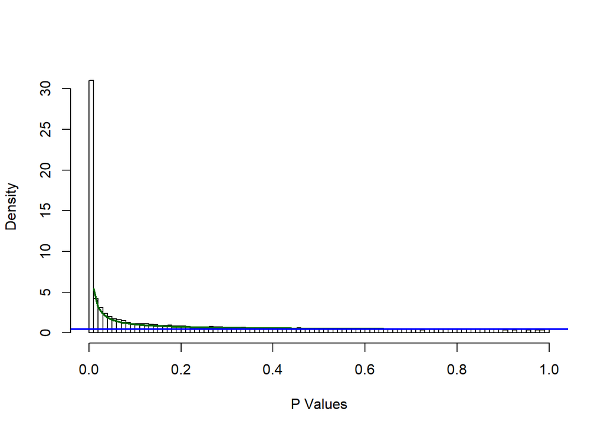

```r
bummlm <- Bum(mlm@p.values)
hist(bummlm)
```

## Question 6c

8516 significant genes at 1% FDR 12409 significnant genes at 5% FDR 15140 significant genes at 10% FDR

```r
countSignificant(bummlm, alpha=0.01, by="FDR")
```

```
## [1] 8516
```

```r
countSignificant(bummlm, alpha=0.05, by="FDR")
```

```
## [1] 12409
```

```r
countSignificant(bummlm, alpha=0.10, by="FDR")
```

```
## [1] 15140
```

## Question 7a

```r
Components <- as.data.frame(clinical.info[,c(4,6)])
mlm2 <- MultiLinearModel(Y ~ Status + ChipType, Components, expression.data)
summary(mlm2)
```

```
## Row-by-row linear models with 28947 rows
##
## Call: MultiLinearModel(form = Y ~ Status + ChipType, clindata = Components, arraydata = expression.data)
##
## F-statistics:
##      Min.   1st Qu.    Median      Mean   3rd Qu.      Max.
##   0.00361   1.70606   3.87331   6.57033   8.10265 224.88873
##
## P-values:
```

```
##      Min.   1st Qu.    Median      Mean   3rd Qu.      Max.
## 0.0000000 0.0000645 0.0112657 0.1388327 0.1700798 0.9996996
```

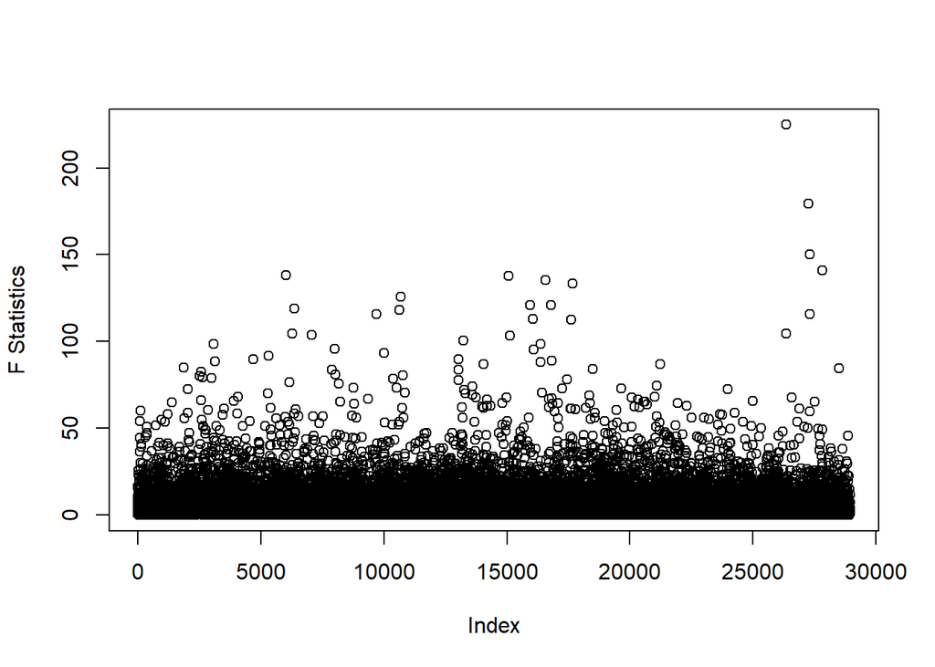

```r
plot(mlm2)
```

```r
anova <- anova(mlm,mlm2)

summary(anova)
```

```
##   F.statistics         p.values
##  Min.   :  0.0000   Min.   :0.000000
##  1st Qu.:  0.5571   1st Qu.:0.004016
##  Median :  2.6607   Median :0.105743
##  Mean   :  8.1874   Mean   :0.255165
##  3rd Qu.:  8.6399   3rd Qu.:0.457040
##  Max.   :570.2208   Max.   :0.999992
```

```r
bummlm2 <- Bum(mlm2@p.values)

countSignificant(bummlm2, alpha=0.01, by="FDR")
```

```
## [1] 16848
```

## Question 7b

```r
Chip <- as.data.frame(clinical.info$ChipType)
rownames(Chip) = rownames(clinical.info)
colnames(Chip) = 'ChipType'
mlm3 <- MultiLinearModel(Y ~ ChipType, Chip, expression.data)
summary(mlm3)
```

```
## Row-by-row linear models with 28947 rows
##
## Call: MultiLinearModel(form = Y ~ ChipType, clindata = Chip, arraydata = expression.data)
##
## F-statistics:
##     Min.  1st Qu.   Median     Mean  3rd Qu.     Max.
##   0.0000   0.5163   2.4865   7.8935   8.3217 447.4979
##
## P-values:
```

```
##     Min.  1st Qu.   Median     Mean  3rd Qu.     Max.
## 0.000000 0.004715 0.117695 0.261273 0.473965 0.999930
```

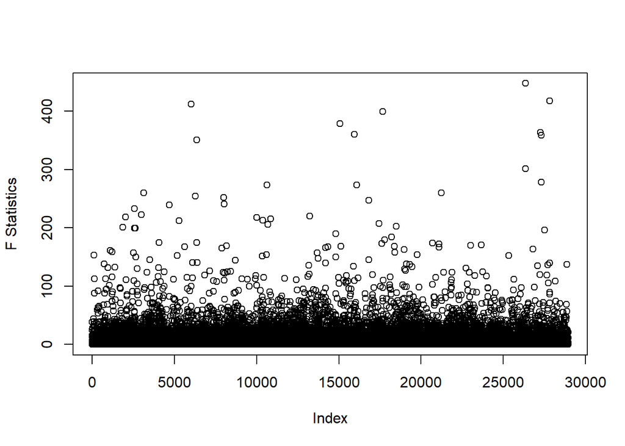

```r
plot(mlm3)
```

```r
bummlm3 <- Bum(mlm3@p.values)

countSignificant(bummlm3, alpha=0.01, by="FDR")
```

```
## [1] 7607
```